# PA1_template.Rmd

Load the data and change date column to date format.

```r
df<-read.csv("activity.csv")
df$date <- as.Date(df$date)
```

# What is mean total number of steps taken per day?

For this part of the assignment, you can ignore the missing values in the dataset. Calculate the total number of steps taken per day.

```r
stepsPerDay<-aggregate(steps~date, data=df, FUN=sum, na.rm="TRUE")
```

Make a histogram of the total number of steps taken each day.

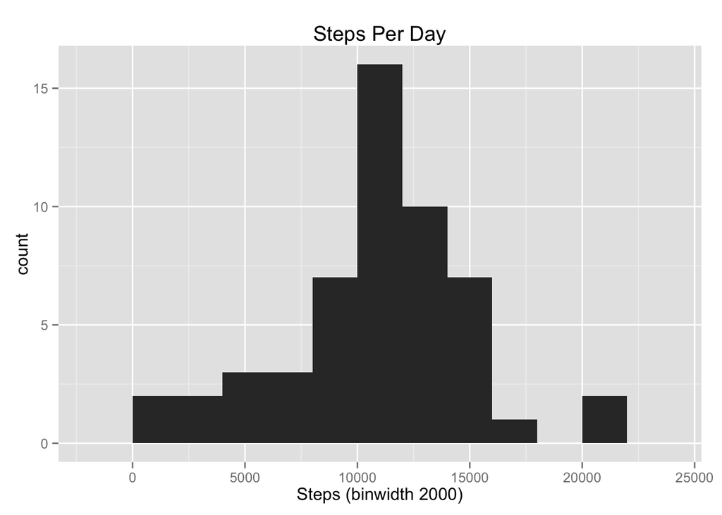

```r
library(ggplot2)
hist <- ggplot(stepsPerDay,aes(x = steps)) +
            ggtitle("Steps Per Day") +
            xlab("Steps (binwidth 2000)") +
            geom_histogram(binwidth = 2000)
hist
```

```r
avg<-mean(stepsPerDay$steps, na.rm="TRUE")
med<-median(stepsPerDay$steps, na.rm="TRUE")
```

# What is the average daily activity pattern?

Make a time series plot (i.e. type = “l”) of the 5-minute interval (x-axis) and the average number of steps taken, averaged across all days (y-axis).

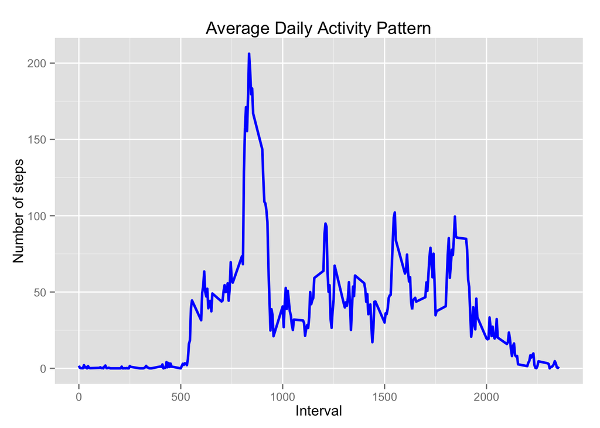

```r
intervalSteps <- aggregate(steps~interval, data=df, FUN=mean, na.rm=TRUE)

ggplot(intervalSteps, aes(x=interval, y=steps)) +
  geom_line(color="blue", size=1) +
  labs(title="Average Daily Activity Pattern", x="Interval", y="Number of steps")
```

```r
maxInterval <- intervalSteps[which.max(intervalSteps$steps),]
```

# Impute missing values

Note that there are a number of days/intervals where there are missing values (coded as NA). The presence of missing days may introduce bias into some calculations or summaries of the data.

```r
numNA <- nrow(df[which(is.na(df$steps)),])
```

Devise a strategy for filling in all of the missing values in the dataset. Strategy: use mean value.

Create a new dataset that is equal to the original dataset but with the missing data filled in.

```r
dfNew <- transform(df,
                   steps=ifelse(is.na(df$steps),
                                intervalSteps[match(intervalSteps$interval,
                                df$interval), ]$steps,
                                df$steps))
```

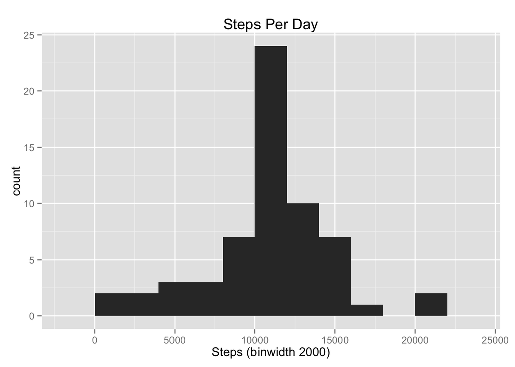

```r
stepsPerDayNew<-aggregate(steps~date, data=dfNew, FUN=sum, na.rm="TRUE")
library(ggplot2)
hist2 <- ggplot(stepsPerDayNew,aes(x = steps)) +
  ggtitle("Steps Per Day") +
  xlab("Steps (binwidth 2000)") +
  geom_histogram(binwidth = 2000)
hist2
```

```r
avgNew<-mean(stepsPerDayNew$steps)
medNew<-median(stepsPerDayNew$steps)
```

# Are there differences in activity patterns between weekdays and weekends?

For this part the weekdays() function may be of some help here. Use the dataset with the filled-in missing values for this part. Create a new factor variable in the dataset with two levels – “weekday” and “weekend” indicating whether a given date is a weekday or weekend day.

```r
dfNew$weekdays <- as.factor(ifelse(weekdays(dfNew$date) %in% c("Saturday", "Sunday"),
                                   "weekend", "weekday"))
```

Make a panel plot containing a time series plot (i.e. type = “l”) of the 5-minute interval (x-axis) and the average number of steps taken, averaged across all weekday days or weekend days (y-axis). See the README file in the GitHub repository to see an example of what this plot should look like using simulated data.

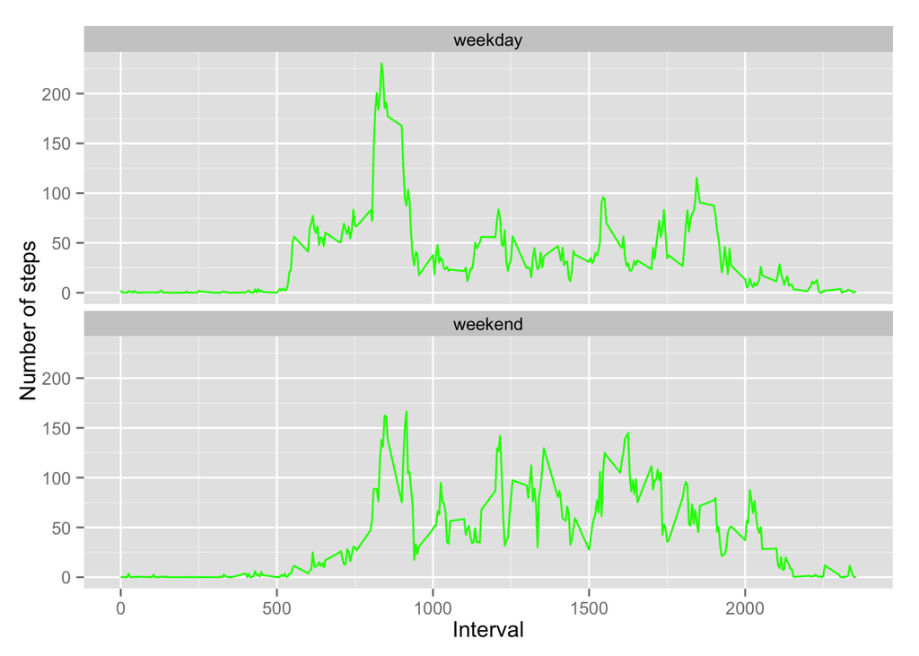

```r
weekAgg <- aggregate(steps ~ weekdays + interval, dfNew, FUN=mean)
ggplot(weekAgg, aes(x=interval, y=steps)) +
  geom_line(color="green") +
  facet_wrap(~ weekdays, nrow=2, ncol=1) +
  labs(x="Interval", y="Number of steps")
```